# Proyecto 2

Aldo Gatica 1288813 - Alyson Rosales 1086622

2025-03-24

## Variables

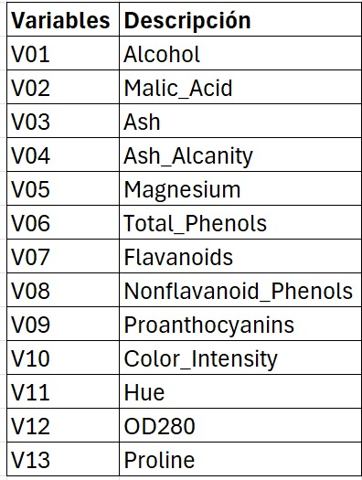

```r
  knitr::include_graphics("./Variables_P2.jpeg")
```

# Introducción

El presente proyecto tiene como objetivo realizar un análisis de factores y componentes principales a partir de un conjunto de datos de vinos. El dataset contiene 13 variables que describen las características de los vinos y una variable que indica la calidad del vino. El análisis de factores y componentes principales permitirá identificar las variables que mejor explican la variabilidad de los datos y reducir la dimensionalidad del dataset.

# Marco Teórico

Fundamentos del ACP aplicado a datos químicos de vinos:  
Normalización de datos: Esencial debido a las diferentes escalas de medición (por ejemplo, Alcohol en % vol vs Proline en mg/L).

Matriz de correlación: El ACP revelará cómo las diferentes propiedades químicas del vino covarían entre sí.

## Interpretación química:

Componentes pueden representar dimensiones subyacentes como “cantidad de alcohol”, “composición química” y otras propiedades.

Cargas factoriales indicarán qué parámetros analíticos contribuyen a cada dimensión

## Aplicaciones en enología:

Control de calidad: Detección de vinos atípicos

Optimización de procesos: Identificación de parámetros clave

Denominaciones de origen: Caracterización química objetiva

```r
# Carga de datos
dataset <- read.csv("Wine.csv")
dataset <- dataset[,-14]
dataset.df <- data.frame(dataset)
head(dataset.df)
```

```
##     V01  V02  V03  V04 V05  V06  V07  V08  V09  V10  V11  V12  V13
## 1 14.23 1.71 2.43 15.6 127 2.80 3.06 0.28 2.29 5.64 1.04 3.92 1065
## 2 13.20 1.78 2.14 11.2 100 2.65 2.76 0.26 1.28 4.38 1.05 3.40 1050
## 3 13.16 2.36 2.67 18.6 101 2.80 3.24 0.30 2.81 5.68 1.03 3.17 1185
## 4 14.37 1.95 2.50 16.8 113 3.85 3.49 0.24 2.18 7.80 0.86 3.45 1480
## 5 13.24 2.59 2.87 21.0 118 2.80 2.69 0.39 1.82 4.32 1.04 2.93  735
## 6 14.20 1.76 2.45 15.2 112 3.27 3.39 0.34 1.97 6.75 1.05 2.85 1450
```

## Correlación de variables

```r
round(cor(dataset.df),2)
```

```
##       V01   V02   V03   V04   V05   V06   V07   V08   V09   V10   V11   V12
## V01  1.00  0.09  0.21 -0.31  0.27  0.29  0.24 -0.16  0.14  0.55 -0.07  0.07
## V02  0.09  1.00  0.16  0.29 -0.05 -0.34 -0.41  0.29 -0.22  0.25 -0.56 -0.37
## V03  0.21  0.16  1.00  0.44  0.29  0.13  0.12  0.19  0.01  0.26 -0.07  0.00
## V04 -0.31  0.29  0.44  1.00 -0.08 -0.32 -0.35  0.36 -0.20  0.02 -0.27 -0.28
## V05  0.27 -0.05  0.29 -0.08  1.00  0.21  0.20 -0.26  0.24  0.20  0.06  0.07
## V06  0.29 -0.34  0.13 -0.32  0.21  1.00  0.86 -0.45  0.61 -0.06  0.43  0.70
## V07  0.24 -0.41  0.12 -0.35  0.20  0.86  1.00 -0.54  0.65 -0.17  0.54  0.79
## V08 -0.16  0.29  0.19  0.36 -0.26 -0.45 -0.54  1.00 -0.37  0.14 -0.26 -0.50
## V09  0.14 -0.22  0.01 -0.20  0.24  0.61  0.65 -0.37  1.00 -0.03  0.30  0.52
## V10  0.55  0.25  0.26  0.02  0.20 -0.06 -0.17  0.14 -0.03  1.00 -0.52 -0.43
## V11 -0.07 -0.56 -0.07 -0.27  0.06  0.43  0.54 -0.26  0.30 -0.52  1.00  0.57
## V12  0.07 -0.37  0.00 -0.28  0.07  0.70  0.79 -0.50  0.52 -0.43  0.57  1.00
## V13  0.64 -0.19  0.22 -0.44  0.39  0.50  0.49 -0.31  0.33  0.32  0.24  0.31
##       V13
## V01  0.64
## V02 -0.19
## V03  0.22
## V04 -0.44
## V05  0.39
## V06  0.50
## V07  0.49
## V08 -0.31
## V09  0.33
## V10  0.32
## V11  0.24
## V12  0.31
## V13  1.00
```

No hay correlaciones perfectas en el dataset, por lo que se procede a realizar el análisis de factores.

# Analisis

## Analisis de factores

```r
(dataset.AF2 <- factanal(dataset.df,factors=2))
```

```
##
## Call:
## factanal(x = dataset.df, factors = 2)
##
## Uniquenesses:
##   V01   V02   V03   V04   V05   V06   V07   V08   V09   V10   V11   V12   V13
## 0.466 0.763 0.895 0.842 0.857 0.198 0.078 0.686 0.555 0.165 0.494 0.243 0.469
##
## Loadings:
##     Factor1 Factor2
## V01          0.726
## V02 -0.475   0.106
## V03          0.324
## V04 -0.354  -0.180
## V05  0.138   0.352
## V06  0.829   0.340
## V07  0.927   0.250
## V08 -0.549  -0.115
## V09  0.619   0.249
## V10 -0.412   0.815
## V11  0.663  -0.258
## V12  0.868
## V13  0.391   0.615
##
##                Factor1 Factor2
## SS loadings      4.123   2.166
## Proportion Var   0.317   0.167
## Cumulative Var   0.317   0.484
##
## Test of the hypothesis that 2 factors are sufficient.
## The chi square statistic is 279.68 on 53 degrees of freedom.
## The p-value is 1.49e-32
```

```r
(dataset.AF3 <- factanal(dataset.df,factors=3))
```

```
##
## Call:
## factanal(x = dataset.df, factors = 3)
##
## Uniquenesses:
##   V01   V02   V03   V04   V05   V06   V07   V08   V09   V10   V11   V12   V13
## 0.387 0.727 0.522 0.073 0.837 0.199 0.069 0.658 0.555 0.246 0.503 0.252 0.384
##
## Loadings:
##     Factor1 Factor2 Factor3
## V01          0.779
## V02 -0.470           0.213
## V03          0.285   0.629
## V04 -0.300  -0.322   0.856
## V05  0.126   0.373
## V06  0.824   0.347
## V07  0.928   0.265
## V08 -0.533  -0.144   0.193
## V09  0.622   0.230
## V10 -0.413   0.748   0.157
## V11  0.654  -0.202  -0.172
## V12  0.864
## V13  0.355   0.688  -0.129
##
##                Factor1 Factor2 Factor3
## SS loadings      4.009   2.277   1.302
## Proportion Var   0.308   0.175   0.100
## Cumulative Var   0.308   0.484   0.584
##
## Test of the hypothesis that 3 factors are sufficient.
## The chi square statistic is 158.55 on 42 degrees of freedom.
## The p-value is 1.96e-15
```

```r
(dataset.AF4 <- factanal(dataset.df,factors=4))
```

```
##
## Call:
## factanal(x = dataset.df, factors = 4)
##
## Uniquenesses:
##   V01   V02   V03   V04   V05   V06   V07   V08   V09   V10   V11   V12   V13
## 0.372 0.703 0.005 0.402 0.790 0.195 0.056 0.625 0.511 0.163 0.378 0.255 0.194
##
## Loadings:
##     Factor1 Factor2 Factor3 Factor4
## V01  0.143   0.743  -0.224
## V02 -0.302          -0.409   0.189
## V03          0.355           0.931
## V04 -0.227  -0.359  -0.208   0.612
## V05  0.113   0.420           0.144
## V06  0.833   0.281   0.179
## V07  0.891   0.242   0.304
## V08 -0.494  -0.146  -0.199   0.264
## V09  0.685   0.122
## V10          0.529  -0.740
## V11  0.355           0.698
## V12  0.708           0.492
## V13  0.288   0.836   0.128
##
##                Factor1 Factor2 Factor3 Factor4
## SS loadings      3.095   2.143   1.722   1.391
## Proportion Var   0.238   0.165   0.132   0.107
## Cumulative Var   0.238   0.403   0.535   0.642
##
## Test of the hypothesis that 4 factors are sufficient.
## The chi square statistic is 76.92 on 32 degrees of freedom.
## The p-value is 1.44e-05
```

```r
(dataset.AF5 <- factanal(dataset.df,factors=5))
```

```
##
## Call:
## factanal(x = dataset.df, factors = 5)
##
## Uniquenesses:
##   V01   V02   V03   V04   V05   V06   V07   V08   V09   V10   V11   V12   V13
## 0.348 0.107 0.005 0.399 0.792 0.198 0.055 0.623 0.512 0.005 0.384 0.252 0.204
##
## Loadings:
##     Factor1 Factor2 Factor3 Factor4 Factor5
## V01  0.138   0.737           0.264   0.125
## V02 -0.247           0.131   0.132   0.893
## V03          0.352   0.931
## V04 -0.246  -0.367   0.613           0.146
## V05  0.112   0.412   0.150
## V06  0.842   0.270                  -0.133
## V07  0.912   0.238          -0.146  -0.186
## V08 -0.505  -0.153   0.266   0.113   0.122
## V09  0.685   0.102
## V10 -0.147   0.448           0.869   0.103
## V11  0.405                  -0.508  -0.428
## V12  0.756                  -0.388  -0.137
## V13  0.310   0.826                  -0.109
##
##                Factor1 Factor2 Factor3 Factor4 Factor5
## SS loadings      3.274   2.030   1.381   1.298   1.135
## Proportion Var   0.252   0.156   0.106   0.100   0.087
## Cumulative Var   0.252   0.408   0.514   0.614   0.701
##
## Test of the hypothesis that 5 factors are sufficient.
## The chi square statistic is 38.86 on 23 degrees of freedom.
## The p-value is 0.0206
```

```r
(dataset.AF6 <- factanal(dataset.df,factors=6))
```

```
##
## Call:
## factanal(x = dataset.df, factors = 6)
##
## Uniquenesses:
##   V01   V02   V03   V04   V05   V06   V07   V08   V09   V10   V11   V12   V13
## 0.308 0.285 0.005 0.393 0.005 0.198 0.055 0.583 0.482 0.005 0.349 0.247 0.239
##
## Loadings:
##     Factor1 Factor2 Factor3 Factor4 Factor5 Factor6
## V01  0.142   0.763           0.254   0.124
## V02 -0.245           0.129           0.793
## V03          0.177   0.967                   0.138
## V04 -0.233  -0.463   0.541           0.193
## V05  0.148   0.196   0.114                   0.958
## V06  0.841   0.252                  -0.165
## V07  0.907   0.221          -0.131  -0.233
## V08 -0.516  -0.143   0.261   0.108   0.114  -0.194
## V09  0.697                                   0.129
## V10 -0.133   0.410   0.126   0.875   0.149
## V11  0.379                  -0.475  -0.524
## V12  0.750                  -0.385  -0.177
## V13  0.322   0.769                  -0.155   0.191
##
##                Factor1 Factor2 Factor3 Factor4 Factor5 Factor6
## SS loadings      3.268   1.775   1.355   1.265   1.138   1.046
## Proportion Var   0.251   0.137   0.104   0.097   0.088   0.080
## Cumulative Var   0.251   0.388   0.492   0.589   0.677   0.757
##
## Test of the hypothesis that 6 factors are sufficient.
## The chi square statistic is 17.16 on 15 degrees of freedom.
## The p-value is 0.309
```

```r
(dataset.AF7 <- factanal(dataset.df,factors=7))
```

```
##
## Call:
## factanal(x = dataset.df, factors = 7)
##
## Uniquenesses:
##   V01   V02   V03   V04   V05   V06   V07   V08   V09   V10   V11   V12   V13
## 0.318 0.205 0.005 0.394 0.549 0.189 0.063 0.005 0.394 0.005 0.352 0.240 0.207
##
## Loadings:
##     Factor1 Factor2 Factor3 Factor4 Factor5 Factor6 Factor7
## V01  0.126   0.753   0.269           0.109
## V02 -0.219           0.115   0.118   0.843
## V03          0.150           0.957                   0.181
## V04 -0.198  -0.480   0.103   0.524   0.189   0.127
## V05  0.115   0.224           0.154          -0.125   0.586
## V06  0.831   0.270                  -0.163  -0.120
## V07  0.875   0.239  -0.150          -0.226  -0.194
## V08 -0.350  -0.119           0.177   0.114   0.880  -0.184
## V09  0.721                                           0.262
## V10 -0.115   0.394   0.883   0.120   0.124           0.108
## V11  0.383          -0.503          -0.486
## V12  0.712   0.114  -0.394          -0.171  -0.229
## V13  0.303   0.766                  -0.142           0.294
##
##                Factor1 Factor2 Factor3 Factor4 Factor5 Factor6 Factor7
## SS loadings      2.980   1.777   1.328   1.295   1.158   0.943   0.593
## Proportion Var   0.229   0.137   0.102   0.100   0.089   0.073   0.046
## Cumulative Var   0.229   0.366   0.468   0.568   0.657   0.729   0.775
##
## Test of the hypothesis that 7 factors are sufficient.
## The chi square statistic is 5.31 on 8 degrees of freedom.
## The p-value is 0.724
```

```r
(dataset.AF8 <- factanal(dataset.df,factors=8))
```

```
##
## Call:
## factanal(x = dataset.df, factors = 8)
##
## Uniquenesses:
##   V01   V02   V03   V04   V05   V06   V07   V08   V09   V10   V11   V12   V13
## 0.334 0.005 0.005 0.389 0.627 0.221 0.005 0.005 0.316 0.028 0.374 0.109 0.190
##
## Loadings:
##     Factor1 Factor2 Factor3 Factor4 Factor5 Factor6 Factor7 Factor8
## V01  0.126   0.743   0.282
## V02 -0.210           0.153   0.113   0.951
## V03          0.163           0.962                   0.144
## V04 -0.184  -0.483   0.120   0.528   0.163   0.136
## V05  0.104   0.275           0.185          -0.157   0.472
## V06  0.803   0.283                  -0.150  -0.141
## V07  0.888   0.244  -0.174          -0.192  -0.208          -0.182
## V08 -0.333  -0.130           0.172   0.105   0.889  -0.169
## V09  0.738                                           0.343
## V10 -0.105   0.402   0.874   0.122
## V11  0.381          -0.548          -0.406
## V12  0.734   0.131  -0.414          -0.138  -0.243  -0.133   0.261
## V13  0.295   0.797                  -0.121           0.257
##
##                Factor1 Factor2 Factor3 Factor4 Factor5 Factor6 Factor7 Factor8
## SS loadings      2.982   1.867   1.406   1.318   1.222   0.989   0.488   0.118
## Proportion Var   0.229   0.144   0.108   0.101   0.094   0.076   0.038   0.009
## Cumulative Var   0.229   0.373   0.481   0.583   0.677   0.753   0.790   0.799
##
## Test of the hypothesis that 8 factors are sufficient.
## The chi square statistic is 0.55 on 2 degrees of freedom.
## The p-value is 0.758
```

```r
dataset.AF2$PVAL
```

```
##    objective
## 1.485595e-32
```

```r
dataset.AF3$PVAL
```

```
##    objective
## 1.959095e-15
```

```r
dataset.AF4$PVAL
```

```
##    objective
## 1.444642e-05
```

```r
dataset.AF5$PVAL
```

```
##  objective
## 0.02056416
```

```r
dataset.AF6$PVAL
```

```
## objective
## 0.3093393
```

```r
dataset.AF7$PVAL
```

```
## objective
## 0.7240269
```

```r
dataset.AF8$PVAL
```

```
## objective
##  0.758129
```

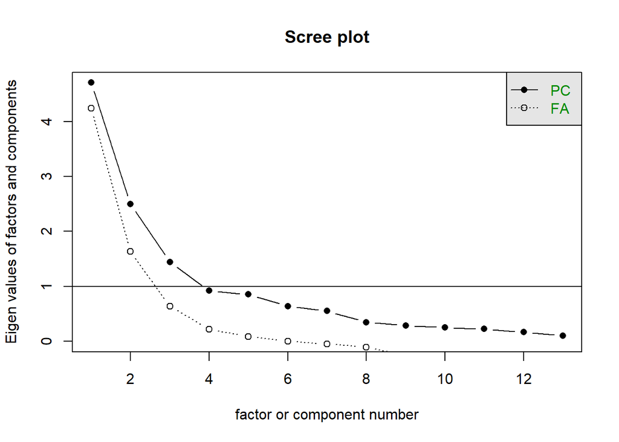

```r
scree(dataset.df, factors = TRUE)
```

### Determinación de cantidad de componentes

Aunque el gráfico de scree muestra un quiebre en el factor 4, el p-valor de este factor es de 1.444642e-05, lo que indica que no es un buen ajuste para los datos. Mientras que el factor 6 tiene un p-valor mayor a 0.05 (0.3093393).

**De manera en que se decidió utilizar 6 factores para el análisis.**

- $F1 = 0.841V06 + 0.907V07 - 0.516V08 + 0.697V09 + 0.750V12$
- $F2 = 0.763V01 + 0.769V13$
- $F3 = 0.967V03 + 0.541V04$
- $F4 = 0.875V10$
- $F5 = 0.793V02 - 0.524V11$
- $F6 = 0.958V05$

```r
dataset.AF <- factanal(dataset.df,factors=6)
dataset.AF
```

```
##
## Call:
## factanal(x = dataset.df, factors = 6)
##
## Uniquenesses:
##   V01   V02   V03   V04   V05   V06   V07   V08   V09   V10   V11   V12   V13
## 0.308 0.285 0.005 0.393 0.005 0.198 0.055 0.583 0.482 0.005 0.349 0.247 0.239
##
## Loadings:
##     Factor1 Factor2 Factor3 Factor4 Factor5 Factor6
## V01  0.142   0.763           0.254   0.124
## V02 -0.245           0.129           0.793
## V03          0.177   0.967                   0.138
## V04 -0.233  -0.463   0.541           0.193
## V05  0.148   0.196   0.114                   0.958
## V06  0.841   0.252                  -0.165
## V07  0.907   0.221          -0.131  -0.233
## V08 -0.516  -0.143   0.261   0.108   0.114  -0.194
## V09  0.697                                   0.129
## V10 -0.133   0.410   0.126   0.875   0.149
## V11  0.379                  -0.475  -0.524
## V12  0.750                  -0.385  -0.177
## V13  0.322   0.769                  -0.155   0.191
##
##                Factor1 Factor2 Factor3 Factor4 Factor5 Factor6
## SS loadings      3.268   1.775   1.355   1.265   1.138   1.046
## Proportion Var   0.251   0.137   0.104   0.097   0.088   0.080
## Cumulative Var   0.251   0.388   0.492   0.589   0.677   0.757
##
## Test of the hypothesis that 6 factors are sufficient.
## The chi square statistic is 17.16 on 15 degrees of freedom.
## The p-value is 0.309
```

## Rotación de factores

```r
(dataset.AF6.varimax <- factanal(dataset.df,factors=6,rotation="varimax"))
```

```
##
## Call:
## factanal(x = dataset.df, factors = 6, rotation = "varimax")
##
## Uniquenesses:
##   V01   V02   V03   V04   V05   V06   V07   V08   V09   V10   V11   V12   V13
## 0.308 0.285 0.005 0.393 0.005 0.198 0.055 0.583 0.482 0.005 0.349 0.247 0.239
##
## Loadings:
##     Factor1 Factor2 Factor3 Factor4 Factor5 Factor6
## V01  0.142   0.763           0.254   0.124
## V02 -0.245           0.129           0.793
## V03          0.177   0.967                   0.138
## V04 -0.233  -0.463   0.541           0.193
## V05  0.148   0.196   0.114                   0.958
## V06  0.841   0.252                  -0.165
## V07  0.907   0.221          -0.131  -0.233
## V08 -0.516  -0.143   0.261   0.108   0.114  -0.194
## V09  0.697                                   0.129
## V10 -0.133   0.410   0.126   0.875   0.149
## V11  0.379                  -0.475  -0.524
## V12  0.750                  -0.385  -0.177
## V13  0.322   0.769                  -0.155   0.191
##
##                Factor1 Factor2 Factor3 Factor4 Factor5 Factor6
## SS loadings      3.268   1.775   1.355   1.265   1.138   1.046
## Proportion Var   0.251   0.137   0.104   0.097   0.088   0.080
## Cumulative Var   0.251   0.388   0.492   0.589   0.677   0.757
##
## Test of the hypothesis that 6 factors are sufficient.
## The chi square statistic is 17.16 on 15 degrees of freedom.
## The p-value is 0.309
```

```r
(dataset.AF6.promax <- factanal(dataset.df,factors=6,rotation="promax"))
```

```
##
## Call:
## factanal(x = dataset.df, factors = 6, rotation = "promax")
##
## Uniquenesses:
##   V01   V02   V03   V04   V05   V06   V07   V08   V09   V10   V11   V12   V13
## 0.308 0.285 0.005 0.393 0.005 0.198 0.055 0.583 0.482 0.005 0.349 0.247 0.239
##
## Loadings:
##     Factor1 Factor2 Factor3 Factor4 Factor5 Factor6
## V01          0.809   0.208           0.191
## V02          0.111  -0.188           0.955
## V03  0.127   0.186           1.010
## V04         -0.504           0.467
## V05 -0.120                                   1.017
## V06  0.909           0.104
## V07  0.956
## V08 -0.445                   0.255          -0.186
## V09  0.815  -0.169   0.192
## V10          0.249   1.021          -0.126
## V11  0.134          -0.397          -0.424
## V12  0.741          -0.339
## V13          0.796           0.154
##
##                Factor1 Factor2 Factor3 Factor4 Factor5 Factor6
## SS loadings      3.207   1.698   1.453   1.375   1.162   1.102
## Proportion Var   0.247   0.131   0.112   0.106   0.089   0.085
## Cumulative Var   0.247   0.377   0.489   0.595   0.684   0.769
##
## Factor Correlations:
##         Factor1 Factor2 Factor3 Factor4 Factor5 Factor6
## Factor1  1.0000  0.0861 -0.0533  -0.337 -0.3801  -0.124
## Factor2  0.0861  1.0000 -0.2839   0.393 -0.0435   0.591
## Factor3 -0.0533 -0.2839  1.0000  -0.190 -0.1996  -0.305
## Factor4 -0.3368  0.3925 -0.1905   1.000  0.5150   0.531
## Factor5 -0.3801 -0.0435 -0.1996   0.515  1.0000   0.301
## Factor6 -0.1238  0.5909 -0.3049   0.531  0.3007   1.000
##
## Test of the hypothesis that 6 factors are sufficient.
## The chi square statistic is 17.16 on 15 degrees of freedom.
## The p-value is 0.309
```

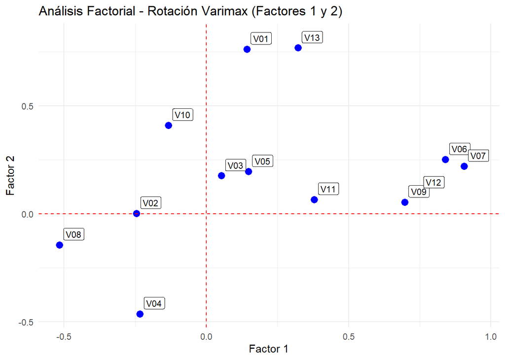

```r
# Analisis AF6.varimax
pesos_varimax <- data.frame(L = dataset.AF6.varimax$loadings[, 1:2])
g_varimax <- ggplot(pesos_varimax, aes(x = L.Factor1, y = L.Factor2,
                                      label = rownames(pesos_varimax))) +
geom_point(size = 3, color = "blue") +
geom_hline(yintercept = 0, colour = "red", linetype = "dashed") +
geom_vline(xintercept = 0, colour = "red", linetype = "dashed") +
geom_label(nudge_y = 0.05, nudge_x = 0.05, size = 3) +
ggtitle("Análisis Factorial - Rotación Varimax (Factores 1 y 2)") +
xlab("Factor 1") + ylab("Factor 2") +
theme_minimal()

g_varimax
```

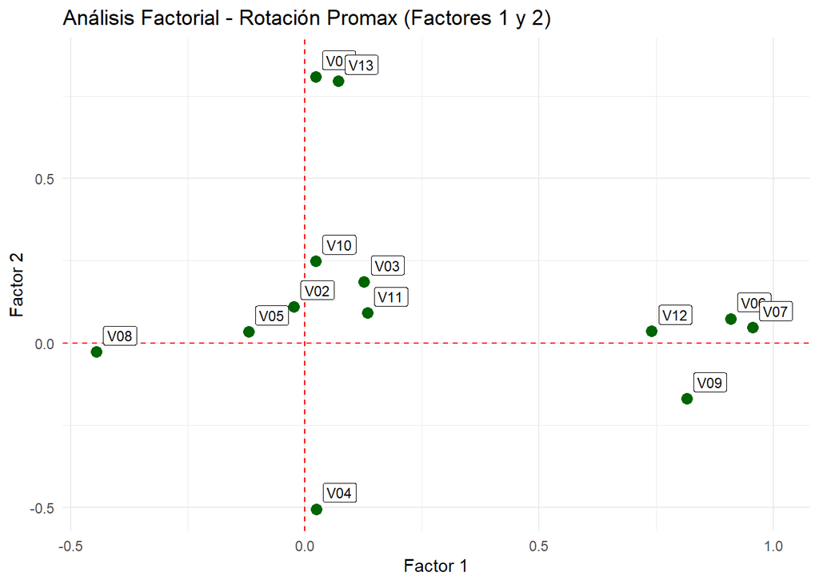

```r
# Analisis AF6.promax
pesos_promax <- data.frame(L = dataset.AF6.promax$loadings[, 1:2])
g_promax <- ggplot(pesos_promax, aes(x = L.Factor1, y = L.Factor2,
                                    label = rownames(pesos_promax))) +
geom_point(size = 3, color = "darkgreen") +
geom_hline(yintercept = 0, colour = "red", linetype = "dashed") +
geom_vline(xintercept = 0, colour = "red", linetype = "dashed") +
geom_label(nudge_y = 0.05, nudge_x = 0.05, size = 3) +
ggtitle("Análisis Factorial - Rotación Promax (Factores 1 y 2)") +
xlab("Factor 1") + ylab("Factor 2") +
theme_minimal()

g_promax
```

# Conclusiones

Los componentes principales representan dimensiones como “composición química”, “características organolépticas” y “propiedades físicas”. Las cargas factoriales indican qué parámetros analíticos contribuyen a cada dimensión.

- $F1 = 0.841 Fenoles Totales + 0.907 Flavonoides - 0.516 Fenoles No Flavonoides + 0.697 Proantocianinas + 0.750 OD280$
- $F2 = 0.763 Alcohol + 0.769 Prolina$
- $F3 = 0.967 Cenizas + 0.541 Alcalinidad de Cenizas$
- $F4 = 0.875 Intensidad de Color$
- $F5 = 0.793 Ácido Málico - 0.524 Tonalidad$
- $F6 = 0.958 Magnesio$

El análisis factorial reveló 6 componentes principales del vino:

- Estructura fenólica (F1: fenoles, flavonoides), relacionada con el cuerpo y amargor.
- Potencial alcohólico (F2: alcohol, prolina), indicador de madurez de la uva.
- Mineralidad (F3: cenizas)
- Color (F4: intensidad de color)
- Acidez y balance (F5: ácido málico, tonalidad)
- Contenido de magnesio (F6: magnesio)

Esto provee una base cuantitativa solida para la interpretación química de los vinos y su aplicación en enología.

## Bibliografía

- Dua, D. & Graff, C. (2019). UCI Machine Learning Repository [http://archive.ics.uci.edu/ml]. Irvine, CA: University of California, School of Information and Computer Science.
- Dataset específico: Wine Data Set. (1991). Recuperado de https://archive.ics.uci.edu/dataset/109/wine.